# Difference-in-Differences

Natasha Kang

Xiamen University, Chow Institute

May, 2026

## 6a Recap

Continuous $X_{it}$. Linear additive PO function:

$$Y_{it}(x) = \alpha_i + \lambda_t + x'\beta + \varepsilon_{it}$$

— linearity and a **homogeneous slope $\beta$** are part of the structural assumption.

Empirical model ($Y_{it}$ = PO at the realized $X_{it}$):

$$Y_{it} = \alpha_i + \lambda_t + X_{it}'\beta + \varepsilon_{it}$$

Identifying assumption: strict exogeneity on $\varepsilon$ $\Rightarrow$ estimate $\beta$ by TWFE.

## What’s Different in DiD

**Setting** — binary policy switch:

$$D_{it} = G_i \cdot \mathbf{1}[t \geq t^*]$$

**Potential outcomes.** Binary $D$ gives two POs per unit-period: $Y_{it}(0)$ and $Y_{it}(1)$. Write

$$Y_{it}(1) = Y_{it}(0) + \tau_i$$

with $\tau_i$ unrestricted — *no homogeneous-slope assumption*. What the design recovers:

$$\text{ATT} \;=\; E[\tau_i \mid G_i = 1]$$

— the mean effect *on the treated*. ATE would require restrictions on $Y(1)$ too.

**Next**: Card & Krueger (1994) — DiD with two groups and two periods.

## Minimum Wage and Employment: Card & Krueger (1994)

**Question**: Does raising the minimum wage reduce employment?

**Policy**: April 1992 — New Jersey raises minimum wage from $4.25 to $5.05. Pennsylvania does not.

**Data**:

- 410 fast-food restaurants in NJ and eastern PA — a minimum-wage-intensive industry, with wages tightly tied to the legal floor.
- Surveyed before (Feb–Mar 1992) and after (Nov–Dec 1992).

**Outcome**: average employment per restaurant.

## Why Naive Comparisons Fail

**Cross-sectional** — NJ vs. PA, after the hike:

$$\bar Y_{\text{NJ, after}} \;-\; \bar Y_{\text{PA, after}}$$

Confounded by *pre-existing differences* between states.

**Before-after** — NJ alone, before vs. after:

$$\bar Y_{\text{NJ, after}} \;-\; \bar Y_{\text{NJ, before}}$$

Confounded by *time trends* — economy-wide changes between Feb and Nov 1992.

DiD combines the two to **cancel each one’s bias** — formalized below.

## The 2×2 Design

Two groups, two periods. Let:

- $G_i \in \{0, 1\}$: group (treated = 1, control = 0)
- $T_t \in \{0, 1\}$: time (after = 1, before = 0)

The treatment indicator is the product:

$$D_{it} = G_i \cdot T_t$$

— equals 1 only in the **(treated, after)** cell.

|  | $T = 0$ (before) | $T = 1$ (after) |
| --- | --- | --- |
| $G = 1$ (treated) | $D = 0$ | $D = 1$ |
| $G = 0$ (control) | $D = 0$ | $D = 0$ |

We observe outcome $Y_{it}$ for every unit-period.

## Potential Outcomes

For each unit-period $(i, t)$, define:

- $Y_{it}(0)$ — outcome **without** treatment.
- $Y_{it}(1)$ — outcome **with** treatment.

The observed outcome equals the PO under realized treatment:

$$Y_{it} = D_{it} \cdot Y_{it}(1) + (1 - D_{it}) \cdot Y_{it}(0)$$

**The fundamental problem**: at any $(i, t)$, only one of $\{Y_{it}(0), Y_{it}(1)\}$ is observed. The other is the *counterfactual*.

## Naive 1: Before-After (Treated Only)

Compare the treated group across periods:

$$E[Y_{i1} \mid G=1] \;-\; E[Y_{i0} \mid G=1]$$

Substitute $Y_{i1} = Y_{i1}(1)$ and $Y_{i0} = Y_{i0}(0)$ for the treated group, then add and subtract $E[Y_{i1}(0) \mid G=1]$:

$$\begin{aligned}
&= E[Y_{i1}(1) \mid G=1] - E[Y_{i0}(0) \mid G=1] \\
&= \underbrace{E[Y_{i1}(1) - Y_{i1}(0) \mid G=1]}_{\text{ATT}} + \underbrace{E[Y_{i1}(0) - Y_{i0}(0) \mid G=1]}_{\text{time trend (treated)}}
\end{aligned}$$

## Naive 2: Cross-Section (Post-Period Only)

Compare treated and control after treatment:

$$E[Y_{i1} \mid G=1] \;-\; E[Y_{i1} \mid G=0]$$

Substitute observed = realized PO, then add and subtract $E[Y_{i1}(0) \mid G=1]$:

$$\begin{aligned}
&= E[Y_{i1}(1) \mid G=1] - E[Y_{i1}(0) \mid G=0] \\
&= \underbrace{E[Y_{i1}(1) - Y_{i1}(0) \mid G=1]}_{\text{ATT}} + \underbrace{E[Y_{i1}(0) \mid G=1] - E[Y_{i1}(0) \mid G=0]}_{\text{selection bias}}
\end{aligned}$$

## Combining the Naives

Each naive picks up the ATT plus **one** bias:

- Before-after: treated group’s $Y(0)$-trend.
- Cross-section: group-level $Y(0)$-difference.

**The DiD idea**: subtract the *control’s* before-after change from the *treated’s*. Let $\bar Y_{g,t}$ denote the sample mean for group $g$ in period $t$:

$$\hat\tau^{\text{DiD}} \;=\; \bigl(\bar Y_{1,1} - \bar Y_{1,0}\bigr) \;-\; \bigl(\bar Y_{0,1} - \bar Y_{0,0}\bigr)$$

The control’s change estimates the common $Y(0)$-trend — wiping out the time-trend bias in Naive 1.

Differencing across groups wipes out the group-level $Y(0)$-difference in Naive 2.

Both bias terms vanish — **under an assumption we name next**.

## Parallel Trends

The assumption that makes DiD work:

$$E[Y_{i1}(0) - Y_{i0}(0) \mid G=1] \;=\; E[Y_{i1}(0) - Y_{i0}(0) \mid G=0]$$

**In words**: absent treatment, both groups would experience the **same average change** in $Y$.

**A counterfactual statement**:

- Left side is *unobservable* — the treated group’s no-treatment trend.
- Right side is *observable* — controls are never treated.
- PT equates an unobservable to an observable.

## Parallel Trends — In a Picture

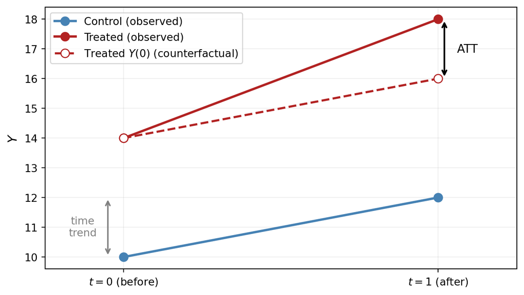

The dashed red line is the missing counterfactual. PT says it slopes the same as the control line. The vertical gap at $t=1$ is the ATT.

## What Parallel Trends Does NOT Require

**Levels can differ.** The treated group can start higher or lower than the control.

**Treatment effects can be heterogeneous.** $Y_{i1}(1) - Y_{i1}(0)$ can vary across units.

**Only the average $Y(0)$-trends must match.** It’s a statement about *one* potential outcome.

**Compared to lect2a’s independence**:

|  | **Independence (lect2a)** | **Parallel trends** |
| --- | --- | --- |
| Statement | $\{Y(0), Y(1)\} \perp D$ | $E[Y_{i1}(0) - Y_{i0}(0) \mid G]$ same across $G$ |
| Levels differ across groups? | ruled out | allowed |
| $\tau_i$ correlated with treatment status? | ruled out | allowed |
| Defended by | randomization | pre-trends test + theory |

## Maintained Assumptions

Beyond PT, DiD inherits one fundamental condition from the PO framework:

**SUTVA (lect1)**:

- No interference — one unit’s treatment doesn’t affect another’s outcome.
- Single version of treatment.

Like any causal inference, DiD breaks if SUTVA fails.

## What DiD Identifies: ATT

The target: the **average treatment effect on the treated** in the post-period:

$$\text{ATT} \;=\; E[Y_{i1}(1) - Y_{i1}(0) \mid G_i = 1]$$

- $E[Y_{i1}(1) \mid G_i = 1]$ — observed (treated, post).
- $E[Y_{i1}(0) \mid G_i = 1]$ — **counterfactual**, reconstructed under PT.

*Why ATT, not ATE?* PT restricts $Y(0)$ only. The control’s change estimates the treated group’s $Y(0)$-counterfactual — but tells us nothing about how *controls* would respond to treatment.

## Identification: DiD $\to$ ATT

Apply LLN to the four cell means. The probability limit:

$$\begin{aligned}
\hat\tau^{\text{DiD}} \;\xrightarrow{p}\; &\bigl(E[Y_{i1}(1) \mid G=1] - E[Y_{i0}(0) \mid G=1]\bigr) \\
&- \bigl(E[Y_{i1}(0) \mid G=0] - E[Y_{i0}(0) \mid G=0]\bigr)
\end{aligned}$$

Add and subtract $E[Y_{i1}(0) \mid G=1]$:

$$\begin{aligned}
=\;& \underbrace{E[Y_{i1}(1) - Y_{i1}(0) \mid G=1]}_{\text{ATT}} \\
&+ \underbrace{E[Y_{i1}(0) - Y_{i0}(0) \mid G=1] - E[Y_{i1}(0) - Y_{i0}(0) \mid G=0]}_{=\,0\text{ under PT}}
\end{aligned}$$

Under parallel trends: $\hat\tau^{\text{DiD}} \xrightarrow{p} \text{ATT}$. ✓

## Card-Krueger: The 2×2 in Numbers

Average employment per restaurant:

|  | NJ ($G=1$) | PA ($G=0$) | Difference |
| --- | --- | --- | --- |
| Before | 20.44 | 23.33 | $-$2.89 |
| After | 21.03 | 21.17 | $-$0.14 |
| **Change** | $+$**0.59** | $-$**2.16** |  |

$$\hat\tau^{\text{DiD}} \;=\; (+0.59) \;-\; (-2.16) \;=\; +2.75$$

- Employment **rose** in NJ relative to PA after the wage hike.
- The design uses only two waves — a strict 2×2 DiD.

## A Surprising Sign

The competitive labor-market intuition predicts $\hat\tau < 0$:

- Bind the price (wage) above market-clearing → quantity (employment) falls.

CK find $\hat\tau > 0$. Two interpretations:

1. **DiD failed**: PT was violated, $\hat\tau$ is biased upward, the “true” effect is negative or zero.
2. **DiD worked**: the competitive model is *wrong* about this labor market.

Subsequent literature has converged on (2). Why? — next.

## Why Did Employment Rise? Rejecting Perfect Competition

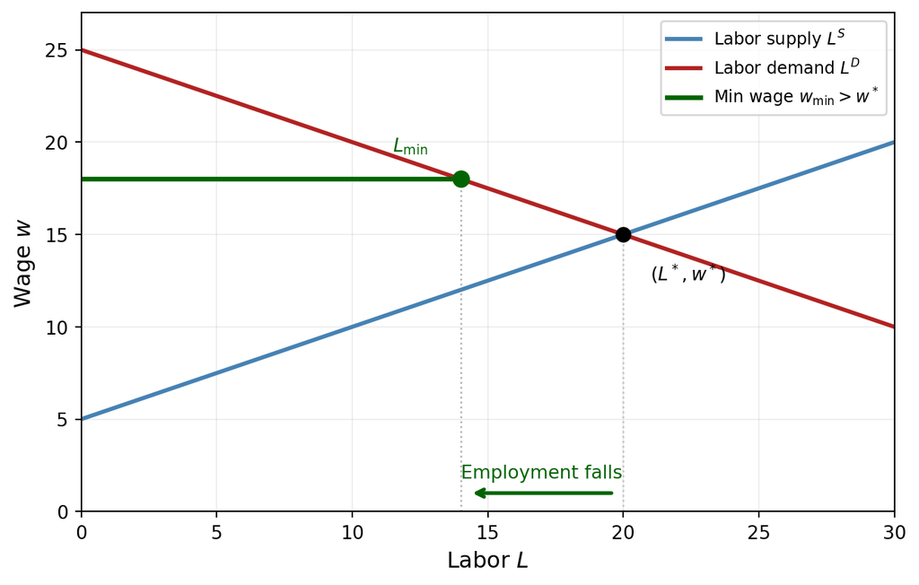

- Wage-taking firms pay competitive wage $w^*$.
- $w_{\min} > w^*$ ⇒ employment falls to $L_{\min}$.
- CK find the opposite — perfect competition is rejected by the data.

## Monopsony Reconciles the Finding

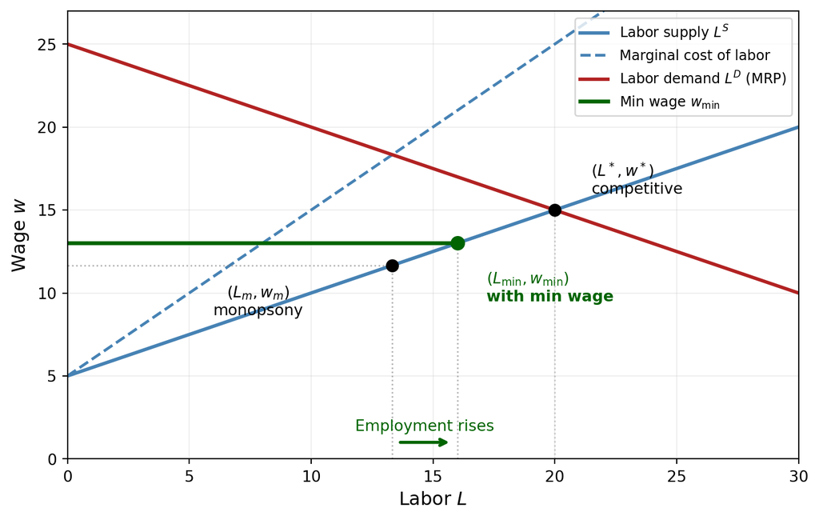

- Monopsony: marginal cost of labor exceeds supply ⇒ hires at $(L_m, w_m)$, below competitive.
- Min wage between $w_m$ and $w^*$ flattens MC ⇒ employment **rises** toward competitive.

## Where Does Wage-Setting Power Come From?

Workers can’t costlessly switch employers:

- Search costs.
- Local commutes — labor markets are small and spatially segmented.
- Heterogeneous job attributes (schedules, locations, benefits).

**Where the literature stands**:

- Manning (2003): widespread evidence of monopsony in low-wage labor markets.
- Azar–Marinescu–Steinbaum (2022): local labor markets often have few competing employers — direct evidence of concentration.
- Post-CK minimum-wage research: moderate hikes show small/zero employment effects — consistent with frictional monopsony.

**The CK lesson**: a credible causal estimate can overturn a textbook prediction.

## From Cell Means to Regression

We’ve built DiD as a four-cell calculation. A regression form lets us:

1. **Compute the same number in standard software.**
2. **Get standard errors and confidence intervals.**
3. **Add covariates** for precision or to relax PT.
4. **Generalize naturally** to many units and many periods.

The translation: replace the 2×2 cell structure with **dummies and an interaction**.

## The 2×2 DiD Regression

Map the four cell means to a regression with dummies and an interaction:

$$Y_{it} \;=\; \alpha \;+\; \beta\, G_i \;+\; \gamma\, T_t \;+\; \tau\,(G_i \times T_t) \;+\; U_{it}$$

Reading off the coefficients:

- $\alpha$: **baseline** — control group, pre-period.
- $\beta$: **group dummy** — level shift for treated.
- $\gamma$: **time dummy** — common shift after period.
- $\tau$: **interaction** — *extra* shift for the (treated, after) cell. **The DiD estimator.**

$\tau$ identifies the ATT under PT — proved on the Identification slide earlier.

## Interpretation: One Conditional Mean Per Cell

|  | $T = 0$ | $T = 1$ |
| --- | --- | --- |
| $G = 0$ | $\alpha$ | $\alpha + \gamma$ |
| $G = 1$ | $\alpha + \beta$ | $\alpha + \beta + \gamma + \tau$ |

Read off:

- Control change: $(\alpha + \gamma) - \alpha = \gamma$.
- Treated change: $(\alpha + \beta + \gamma + \tau) - (\alpha + \beta) = \gamma + \tau$.
- Difference of changes: $\tau$.

## OLS Reproduces the Four-Cell Difference

With only group and time dummies plus their interaction, the OLS estimator is:

$$\hat\tau^{\text{OLS}} \;=\; (\bar Y_{1,1} - \bar Y_{1,0}) \;-\; (\bar Y_{0,1} - \bar Y_{0,0})$$

$\hat\tau^{\text{OLS}}$ equals the hand calculation by construction.

**What we gain**: SEs, CIs, and an extension framework — without changing the estimate.

## Adding Controls — Two Motivations

DiD can be augmented with pre-treatment covariates $W_i$. Two distinct motivations, **with different specifications**.

**Motivation 1 — Precision.**

$$Y_{it} \;=\; \alpha + \beta G_i + \gamma T_t + \tau(G_i \times T_t) + \boldsymbol\theta' W_i + U_{it}$$

If $W_i$ predicts $Y$, including it as a level reduces residual variance ⇒ tighter SE on $\hat\tau$. Identification unchanged.

**Motivation 2 — Conditional PT.**

PT may fail unconditionally but hold *within strata of $W_i$*. Needs a different spec — next slide.

## Conditional PT in 2×2

If $W_i$ predicts the *trend*, unconditional PT fails:

$$E[Y_{i1}(0) - Y_{i0}(0) \mid G=1] \neq E[Y_{i1}(0) - Y_{i0}(0) \mid G=0]$$

PT may still hold *given* $W_i$:

$$E[Y_{i1}(0) - Y_{i0}(0) \mid G=1, W_i] \;=\; E[Y_{i1}(0) - Y_{i0}(0) \mid G=0, W_i]$$

## Implementing Conditional PT

Under conditional PT:

- The $Y(0)$-trend can depend on $W$ (but not on $G$, given $W$).
- Equivalently: $W$’s effect on $Y$ may shift between pre and post.
- $\Rightarrow$ include both $W_i$ (level) and $W_i \times T_t$ (interaction) in the regression.

$$Y_{it} = \alpha + \beta G_i + \gamma T_t + \tau(G_i \times T_t) + \boldsymbol\theta' W_i + \boldsymbol\rho'(W_i \times T_t) + U_{it}$$

- $\boldsymbol\theta' W_i$: $W$’s level effect.
- $\boldsymbol\rho'(W_i \times T_t)$: change in $W$’s effect from pre to post.

$W_i$ must be **pre-treatment** (lect4c, *bad controls*).

## Unit Fixed Effects for Precision

CK has 410 restaurants. Replace the group dummy $G_i$ by **unit dummies** $\alpha_i$ — one per restaurant — absorbing each restaurant’s baseline:

$$Y_{it} = \alpha_i + \gamma T_t + \tau(G_i \times T_t) + U_{it}$$

- $\alpha_i$ — one intercept per restaurant. Absorbs state membership $G_i$ and any time-invariant restaurant feature (location, owner, layout).
- The interaction $G_i \times T_t$ is unchanged — same point estimate $\hat\tau$.
- Residual variance shrinks $\Rightarrow$ tighter SEs.

Identification is still **group-level** — PT compares treated and control $Y(0)$-trends. Unit FE is a regression-spec choice for precision, not a shift to unit-level identification.

## Many Periods

Now extend the **design**: suppose we observe restaurants in **multiple months** before and after the policy, not just one pre and one post. Replace the single time dummy $T_t$ by a **period dummy for each calendar period**:

$$Y_{it} = \alpha_i + \lambda_t + \tau\, D_{it} + U_{it}$$

- $\lambda_t$ — one intercept per period (drop one for the dummy trap).
- $D_{it} = G_i \cdot \mathbf{1}[t \geq t^*]$ — treatment indicator (1 only when $i$ is treated *and* $t$ is post).

**Multiple pre-periods make PT testable** — we can check whether the $Y(0)$-trend was parallel *before* treatment. Coming up.

## Can We Test Parallel Trends?

PT is a statement about the **post-period counterfactual** $Y_{i1}(0)$ for the treated group — never observed.

- We **cannot directly test** PT in the treatment period.
- But with **multiple pre-treatment periods**, we can ask: did the groups move together *before* treatment?
- If yes, more plausible that they would have continued to move together absent treatment.

**Caveat**: parallel pre-trends are *necessary but not sufficient* for PT in the post-period. A coincidental shock at $t^*$ could break post-period PT even if pre-trends are clean.

## The Idea: Estimate a Treatment “Effect” Each Period

Replace the single treatment indicator $D_{it}$ by **one indicator per period**, with $k = -1$ omitted as the reference:

$$Y_{it} = \alpha_i + \lambda_t + \sum_{k \neq -1} \beta_k \cdot \mathbf{1}[t - t^* = k] \cdot G_i + \varepsilon_{it}$$

**Notation**: $k = t - t^*$ is **event time** — periods relative to the treatment date.

- $k = 0$: first treated period.
- $k = -1$: last pre-treatment period (the **reference** — see below).
- $k < -1$: earlier pre-periods (**leads**).
- $k \geq 0$: post-periods (**lags**).

## Reading Off $\beta_k$

For a **control** unit ($G_i = 0$): all interaction terms vanish.
$$Y_{it} = \alpha_i + \lambda_t + \varepsilon_{it}$$

For a **treated** unit at event time $k \neq -1$:
$$Y_{it} = \alpha_i + \lambda_t + \beta_k + \varepsilon_{it}$$

So $\beta_k$ is the **treated-vs.-control gap at event time $k$**, *relative to* the gap at $k = -1$.

- $\beta_k$ for $k < -1$: pre-period leads. Should be ≈ 0 if PT holds.
- $\beta_k$ for $k \geq 0$: post-period lags. Dynamic ATT at horizon $k$.

## Pre-Trend Test

Joint hypothesis on the leads:

$$H_0: \beta_{-K} = \beta_{-K+1} = \cdots = \beta_{-2} = 0$$

Tested with a single $F$-statistic (or equivalent Wald test). Two failure modes:

1. **Rejected** — pre-trends are non-flat. PT is suspect.
2. **Not rejected** — consistent with PT, but does *not* prove PT in the post-period.

Always pair the test with a **plot** — a non-rejection can hide trended-but-noisy leads.

## The Event-Study Plot

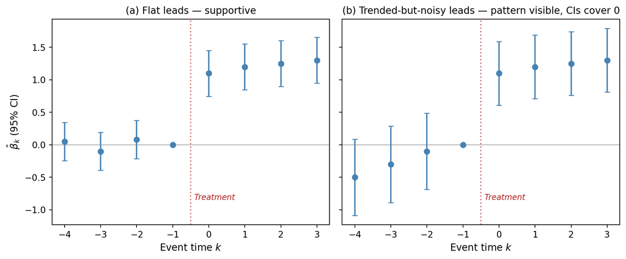

- **(a)** flat leads with CIs covering 0 — supportive of PT.
- **(b)** leads drift linearly toward 0; individual CIs all cover 0 — joint F-test likely doesn’t reject, yet the *pattern* is concerning. PT suspect.

## Standard Errors

Treatment varies at the **group level** (state in CK). Group-level shocks correlate outcomes within group:

- **Serially**: over time within unit.
- **Cross-sectionally**: across units within group at each $t$.

**Cluster at the group** — the level above which observations are independent.

- lect6a TWFE: clustered at **unit** — serial correlation within unit.
- 6b DiD: cluster at **group** — serial + cross-sectional within group.

Few clusters (e.g., 2 states): wild bootstrap, or aggregate to group-period means.

## Exercise: Dropping the Reference Period

In the event-study regression, $k = -1$ is **omitted** from the sum:

$$Y_{it} = \alpha_i + \lambda_t + \sum_{k \neq -1} \beta_k \cdot \mathbf{1}[t - t^* = k] \cdot G_i + \varepsilon_{it}$$

**Q1.** If we *include* every event-time dummy (no reference), what goes wrong with OLS?

**Q2.** Which $k$ should we drop by convention, and what do the remaining $\beta_k$ then measure?

## Anticipation

Recall: $\beta_k$ is measured *relative to $k = -1$*. What if $k = -1$ isn’t a clean baseline — because treated units already shifted behavior in anticipation of $t^*$?

**Slemrod (1995)** — Tax Reform Act of 1986:

- Top marginal rate rose, effective **Jan 1987**.
- Anticipating, high-income earners pulled capital gains, bonuses, and other income *into 1986* — locking in the lower rate.
- Pre-period outcomes reflected anticipation, not a clean no-treatment baseline.
- **Diagnostic**: re-estimate with $k = -2$ as reference. A non-zero $\hat\beta_{-1}$ then flags anticipation.
- **Remedy**: redate the treatment to the **announcement** date, not implementation.

## Staggered Rollout: A Modern Setting

Most modern DiD applications don’t have a single $t^*$. Treatment **rolls out across units at different times**:

- US states adopt a policy in different years.
- Firms get access to a new technology over a multi-year phase-in.
- Hospitals join a payment program on different dates.

The treatment indicator generalizes:

$$D_{it} = \mathbf{1}[t \geq t_i^*]$$

— each unit has its own switch date $t_i^*$. Untreated units have $t_i^* = \infty$.

**Natural approach**: run TWFE with this $D_{it}$ — $y_{it} = \alpha_i + \lambda_t + \tau D_{it} + U_{it}$. But…

## Why Naïve TWFE Breaks Under Staggered Rollout

Three units, four periods. Treatment turns on at different times:

| Unit | $t=1$ | $t=2$ | $t=3$ | $t=4$ |
| --- | --- | --- | --- | --- |
| A (never treated) | 0 | 0 | 0 | 0 |
| B (treated at $t=2$) | 0 | **1** | **1** | **1** |
| C (treated at $t=3$) | 0 | 0 | **1** | **1** |

**Goodman-Bacon (2021)**: TWFE’s $\hat\tau$ is *implicitly* a weighted average of all 2×2 DiDs in the panel. With three units, the implicit comparisons include:

- **A as control for B’s switch** ✓ (clean)
- **A as control for C’s switch** ✓ (clean)
- **C vs B around C’s switch** ✗ — uses B (already treated) as a control

## Modern Estimators for Staggered DiD

**Common principle**: never use *already-treated* units as controls. Build treatment effects from clean comparisons, then aggregate.

**Callaway-Sant’Anna (2021)**: let $\text{ATT}(g, t)$ = treatment effect on units treated at time $g$, measured at time $t$. Estimate each one as a clean 2×2 DiD using never-treated **A** as control.

| Cohort $g$ | $t=2$ | $t=3$ | $t=4$ |
| --- | --- | --- | --- |
| $g = 2$ (B) | $\text{ATT}(2,2)$ | $\text{ATT}(2,3)$ | $\text{ATT}(2,4)$ |
| $g = 3$ (C) | — | $\text{ATT}(3,3)$ | $\text{ATT}(3,4)$ |

Aggregate the cells (non-negative weights) → overall ATT, or average across cohorts at each event-time $k = t - g$.

**Variants on the same principle**: Sun-Abraham (event study), dCdH (newly-treated vs not-yet-treated), BJS (impute counterfactual).